# PML

StudentX

Sunday, October 26, 2014

### Summary

The goal of this studio is to predict the manner in which people do their exercises. Based on a set of records the training habits of people was studied by developing a model using the Random Forest approach. The dataset contains 160 variables. One of them, called “classe” is the target to predict and the others 159 are going to be analysed in order to determine whether or not they are useful for our model.

### Loading data

Based on the “pml.training” dataset, a Random Forest model is developed. Subsequently, the model is verified using “pml-testing” dataset to check its accuracy.

### Determining the predictors

The target variable (classe) is a categorical variable and has five different values: A, B, C, D, E. Next, the columns of the training dataset are analyzed to determine which of them are irrelevant for the model. The following variables are removed:

- X
- user_name
- cvtd_timestamp
- The variable “new_window”, By making a summary of this variable we can see that it takes two different values: “no” and “yes” but the value “yes” has lowest representation, so it is not going to be a useful predictor and will be removed.

```r
# By making a summary of this variable we can see that it takes two different values: "no" and "yes" but value. "yes" has lowest representation, so it is not going to be a useful predictor and will be removed.

summary(training$new_window)
```

```
##    no   yes
## 19216   406
```

```r
# Remove this four variables
training1 <- training[, -c(1, 2, 5, 6)]
```

- There are a lot variables with a lot of “null” values, so we can remove them because they are uninformed and they are not going to be predictors: For doing that automatically we are going to make a function that count the number of NA values for each column and if its value is greater than 20% of the rows, they will be removed.

```r
clean_table <- function(table_in) {

        ## table_in: input dataset
        ## return a cleaned dataset without unnecessary variables

        # Get number of columns
        cols <- ncol(table_in)
        rows <- nrow(table_in)

        # Array with the column id to delete
        delete_col <- c()

        # Calculate the number of NA values for each column except "classe" column (our target)
        for( i in 1:cols-1){

                # Get number of NAÂ´S values
                tmp <- nrow(table_in[is.na(as.numeric(as.character(table_in[, i]))), ])

                # We suppose that a variable having more than 20% of its values equal to NA
                # Is going to be a bad predictor, so we will remove it from the input table
                if(tmp > round(0.20 * rows, 0)){
                        delete_col <- c(delete_col, i)
                }
        }

        # Create a new datset without all the columns that have more than 20% of NA values.
        table_out <- table_in[, -delete_col]

        table_out
}

training2 <- clean_table(training1)
```

```r
# Create a correlated matrix with all variables except our target (classe)
correlated <- abs(cor(training2[, -56]))
diag(correlated) <- 0 # All variables have a correlation of 1 with themselves
correlated <- which(correlated > 0.8, arr.ind=T)

length(unique(sort(correlated)))
```

```
## [1] 22
```

As we can see, there are a lot of correlated variables (22). Our model based on Random Forest approach will decide what are the best predictors for our target, so it is not necessary to make combinations of our initial variables.

### Cross-Validation

Using Cross-Validation techniques, we are going to sample our training dataset in two new tables: training3 and testing3. Training dataset has about 20.000 rows, so we can take a sample about 60-70 % of the total size and in this way, we will have two new dataset for test our model approach.

For accurate modeling we use samples higher than 1000 rows, so in this case, we will get a training sample with about 20% of the total size for training.

Now we are going to take a sample of the 20%.

```r
# Get training sample (20% of the total training dataset size)
inTrain <- createDataPartition(y = training2$classe, p=0.2, list=FALSE)
training3 <- training2[inTrain, ]
testing3 <- training2[-inTrain, ]
```

### Random Forest approach

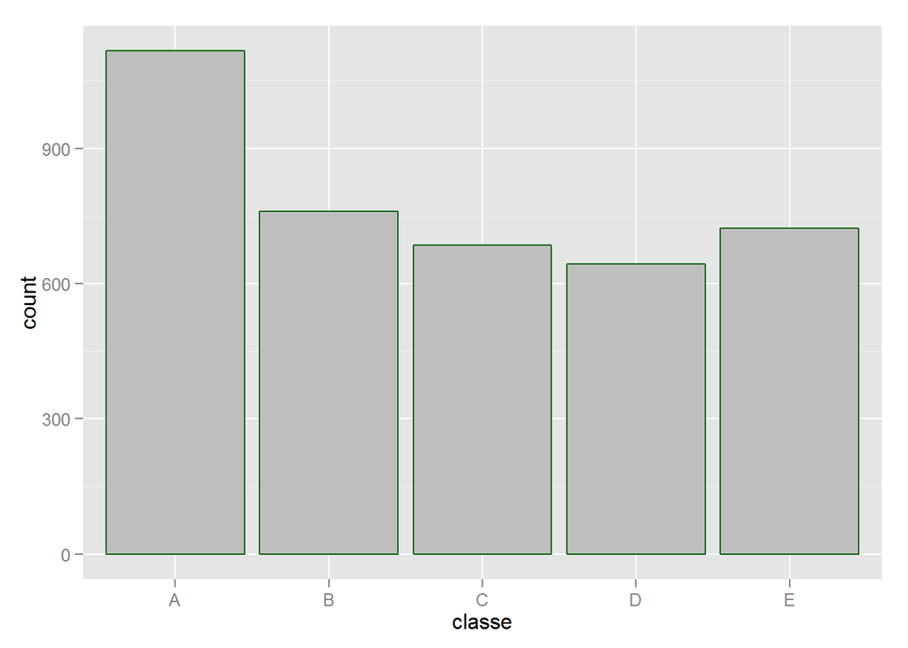

```r
# Plot our categorical target "classe" to see how it looks like
qplot(classe, data=training3) + geom_histogram(colour = "darkgreen", fill = "grey")
```

```r
# Set seed to repeat test
set.seed(1234)

# Fit the model
modFit <- train(classe ~ ., data=training3, method="rf", prox=TRUE)
# See model result:
# 55 predictors
# optimal model with mtry = 28
print(modFit)
```

```
## Random Forest
##
## 3927 samples
##   55 predictor
##    5 classes: 'A', 'B', 'C', 'D', 'E'
##
## No pre-processing
## Resampling: Bootstrapped (25 reps)
##
## Summary of sample sizes: 3927, 3927, 3927, 3927, 3927, 3927, ...
##
## Resampling results across tuning parameters:
##
##   mtry  Accuracy  Kappa  Accuracy SD  Kappa SD
##    2    1         1      0.006        0.007
##   28    1         1      0.003        0.004
##   55    1         1      0.005        0.006
##
## Accuracy was used to select the optimal model using  the largest value.
## The final value used for the model was mtry = 28.
```

```r
# See final model
print(modFit$finalModel)
```

```
##
## Call:
##  randomForest(x = x, y = y, mtry = param$mtry, proximity = TRUE)
##                Type of random forest: classification
##                      Number of trees: 500
## No. of variables tried at each split: 28
##
##         OOB estimate of  error rate: 1.04%
## Confusion matrix:
##      A   B   C   D   E class.error
## A 1114   2   0   0   0    0.001792
## B    7 747   6   0   0    0.017105
## C    0   7 676   2   0    0.013139
## D    0   0   6 636   2    0.012422
## E    0   1   0   8 713    0.012465
```

```r
# Get the specific selected tree (28)
selectedTree <- getTree(modFit$finalModel, k=28)
```

### Testing the model

Now we can predict on new samples to see how good is our approach. We are going to use our “testing3” dataset, obtained when we made the partition based on the training dataset.

```r
predictions <- predict(modFit, testing3)

confusionMatrix(predictions, testing3$classe)
```

```
## Confusion Matrix and Statistics
##
##           Reference
## Prediction    A    B    C    D    E
##          A 4464   22    0    0    0
##          B    0 2982   38    0    0
##          C    0   33 2695   19    0
##          D    0    0    4 2542    1
##          E    0    0    0   11 2884
##
## Overall Statistics
##
##                Accuracy : 0.992
##                  95% CI : (0.99, 0.993)
##     No Information Rate : 0.284
##     P-Value [Acc > NIR] : <2e-16
##
##                   Kappa : 0.99
##  Mcnemar's Test P-Value : NA
##
## Statistics by Class:
##
##                      Class: A Class: B Class: C Class: D Class: E
## Sensitivity             1.000    0.982    0.985    0.988    1.000
## Specificity             0.998    0.997    0.996    1.000    0.999
## Pos Pred Value          0.995    0.987    0.981    0.998    0.996
## Neg Pred Value          1.000    0.996    0.997    0.998    1.000
## Prevalence              0.284    0.194    0.174    0.164    0.184
## Detection Rate          0.284    0.190    0.172    0.162    0.184
## Detection Prevalence    0.286    0.192    0.175    0.162    0.184
## Balanced Accuracy       0.999    0.989    0.990    0.994    0.999
```

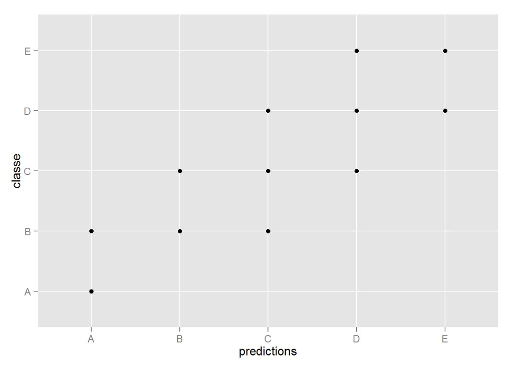

```r
# Print predictions
qplot(predictions, classe, data=testing3)
```

## Applyin the model to the given data set

Finally, the model is applied to the 20 test cases to verify its accuracy.

```r
pred <- predict(modFit, testing)

# B A B A A E D B A A B C B A E E A B B B
pred
```

```
##  [1] B A B A A E D B A A B C B A E E A B B B
## Levels: A B C D E
```